# p8105_hw1_yx2507

```r
library(tidyverse)
```

# problem 1

## making data frame

```r
 problem_1=tibble(
   vec_numeric=rnorm(8),
   vec_logical=vec_numeric>0,
   vec_char=c("a","b","c","d","e","f","g","h"),
   vec_factor = factor(c("M","F","M","F","M","F","M","F"))

 )
#CHECK DATA FRAME
problem_1
```

```
## # A tibble: 8 x 4
##   vec_numeric vec_logical vec_char vec_factor
##         <dbl> <lgl>       <chr>    <fct>
## 1       0.839 TRUE        a        M
## 2       0.131 TRUE        b        F
## 3       1.54  TRUE        c        M
## 4      -0.544 FALSE       d        F
## 5      -0.716 FALSE       e        M
## 6       0.324 TRUE        f        F
## 7      -1.93  FALSE       g        M
## 8       0.176 TRUE        h        F
```

## now take the mean

The result shows that numeric vairable and logical variable work while factor and character vairable can’t get the mean.

```r
mean(problem_1$vec_numeric)
```

```
## [1] -0.02240293
```

```r
mean(problem_1$vec_logical)
```

```
## [1] 0.625
```

```r
mean(problem_1$vec_char)
```

```
## [1] NA
```

```r
mean(problem_1$vec_fator)
```

```
## [1] NA
```

## Conercion

Tn the below steps: * convert the logical vector to numeric, and multiply the random sample by the result * convert the logical vector to a factor, and multiply the random sample by the result * convert the logical vector to a factor and then convert the result to numeric, and multiply the random sample by the result

```r
as.numeric(problem_1$vec_char)
```

```
## [1] NA NA NA NA NA NA NA NA
```

```r
as.numeric(problem_1$vec_logical)
```

```
## [1] 1 1 1 0 0 1 0 1
```

```r
as.numeric(problem_1$vec_factor)
```

```
## [1] 2 1 2 1 2 1 2 1
```

coercision can change charactor vairable into N/A but can’t convert to numeric variable. So it can’t be calculated mean. While for logical variable, when converting to numerica vairables, “True” and “False” can be covert to 1 and 0 respectively. For factor variable, they can convert to the number indicating its level.

## multiply by random sample

```r
as.numeric(problem_1$vec_logical)*rnorm(8)
```

```
## [1] -0.2536833 -0.5882353 -1.0338134  0.0000000  0.0000000  0.1316000
## [7]  0.0000000 -0.5888526
```

```r
as.factor(problem_1$vec_logical)*rnorm(8)
```

```
## [1] NA NA NA NA NA NA NA NA
```

```r
as.numeric(as.factor(problem_1$vec_logical))*rnorm(8)
```

```
## [1]  2.3298009  2.3254699 -0.8715726 -0.4918412  0.9497826  1.4155009
## [7]  0.5465224 -0.8026391
```

# Problem 2 Including Plots

## Create data frame

Create a data frame comprised of: x: a random sample of size 500 from a standard Normal distribution y: a random sample of size 500 from a standard Normal distribution A logical vector indicating whether x + y > 1 A numeric vector created by coercing the above logical vector A factor vector created by coercing the above logical vector

```r
set.seed(2)
  x=rnorm(500)
  y=rnorm(500)
  vec_logical_plot= x + y > 1
  vec_num = as.numeric(vec_logical_plot)
  vec_fact = as.factor(vec_logical_plot)

plot_df=tibble(x,y,vec_logical_plot,vec_fact,vec_num)

head(plot_df)
```

```
## # A tibble: 6 x 5
##         x      y vec_logical_plot vec_fact vec_num
##     <dbl>  <dbl> <lgl>            <fct>      <dbl>
## 1 -0.897  -0.460 FALSE            FALSE          0
## 2  0.185   0.618 FALSE            FALSE          0
## 3  1.59   -0.720 FALSE            FALSE          0
## 4 -1.13   -0.584 FALSE            FALSE          0
## 5 -0.0803  0.216 FALSE            FALSE          0
## 6  0.132   1.24  TRUE             TRUE           1
```

## create scatterplot

color the logical vairable

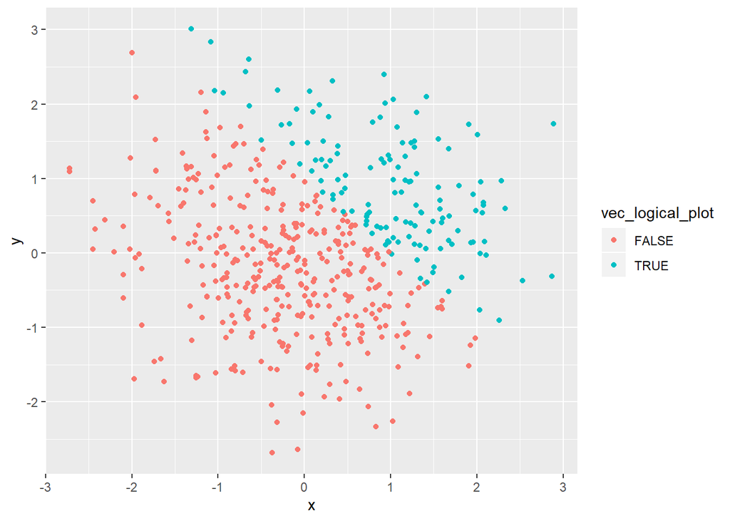

```r
ggplot(plot_df, aes(x = x, y = y, color=vec_logical_plot)) + geom_point()
```

color the factor variable

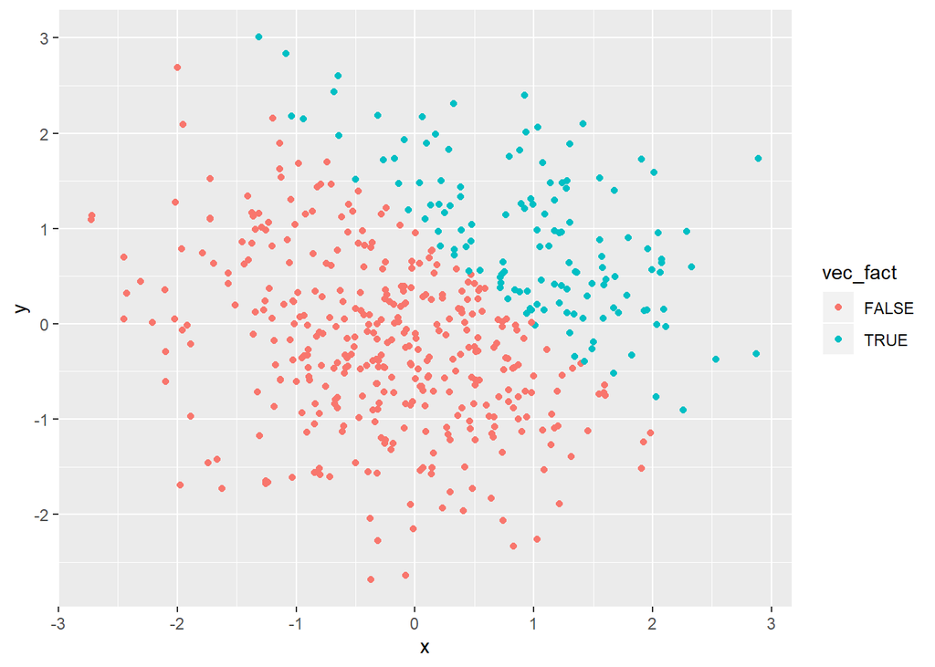

```r
ggplot(plot_df, aes(x = x, y = y, color=vec_fact)) + geom_point()
```

colort the numeric varaible

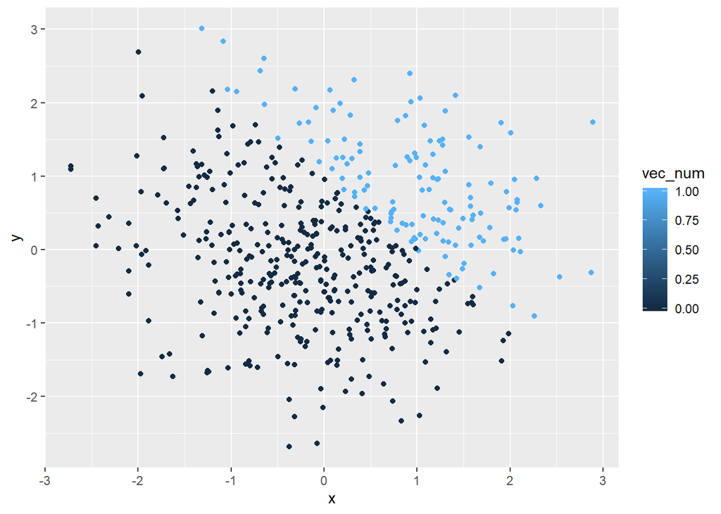

```r
ggplot(plot_df, aes(x = x, y = y, color=vec_num)) + geom_point()
```

## export the this scatterplot

```r
ggsave("scatter_plot.pdf",height=4,width=6)
```